Title: **Clonotypy Preview**  
Author: **Matt Femia**  
Date: **07/13/2021**  
License: **BSD-3**  
Version: **0.1.0**

# Clonotypy

### Clonotypy is a package for analyzing single cell immune profile data.

The primary purpose of Clonotypy is to provide easy access to complex analysis of scVDJ-seq runs. It has support for comparing several scVDJ-seq samples from various pre-processing pipelines, descriptive and multivariate statistics, multi-omic analysis, advanced visualization, and API integrations to many common immunology databases.

**This notebook was created to demonstrate basic functions by showing descriptive analysis functions used on a single sample of scTCR-seq data.**

## Contents:

1. Analysis Preparation  
   i. Dependencies  
   ii. `Repseq` Object
2. Descriptive Data Analysis  
   i. Clonotype Frequency Counts  
   ii. Clonotype Frequency Distribution  
   iii. VDJ Gene Frequency  
   iv. V-J Network Graphs  
   v. CDR3 Lengths  
   vi. CDR3 Composition
3. Beyond The Basics

## Preparation

### Dependencies

```python
import clonotypy as clp
import pandas as pd
```

### Repseq Object

The raw sequencing data for this tutorial was processed using [10X Genomics' CellRanger Pipeline](https://support.10xgenomics.com/single-cell-vdj/software/pipelines/latest/what-is-cell-ranger). A standard output of this pipeline is a file named **filtered_contig_annotations.csv**, which contains contig-level information about the assembled clonotypes resulting from VDJ-sequencing. More information on the VDJ-specific algorithms in the pipeline can be found [here](https://support.10xgenomics.com/single-cell-vdj/software/pipelines/latest/algorithms/overview).

```python
# Read file header from
fca = "data/filtered_contig_annotations.csv" # TCR data
with open(fca, 'r') as f:
    print('filtered_contig_annotations.csv File Header:\n')
    f.readline().rstrip()
```

```
filtered_contig_annotations.csv File Header:
```

```python
# Create Repseq Objects
clones = clp.Repseq(fca)
```

```python
# Describing the Repseq Object
print(f'clones is of type: {type(clones)}\n')
print(f'Repseq class is a subclass of a Pandas DataFrame: {issubclass(clp.Repseq, pd.core.frame.DataFrame)}\n')
print(f'Repseq-specific methods: \n{set(dir(clp.Repseq)).symmetric_difference(set(dir(pd.core.frame.DataFrame)))}')
```

```
clones is of type: <class 'clonotypy.core.Repseq'>

Repseq class is a subclass of a Pandas DataFrame: True

Repseq-specific methods:
{'concat_Repseq', 'to_PositionMatrix', 'plot_clonotype_dist', 'tenx_file_format', 'to_Network', 'calc_frequency', 'count_ig_isotypes', 'melt_cdr3', 'describe_clonotypes', 'to_GeneTable', 'to_cdr3Table', 'plot_top_clonotypes'}
```

As shown above, `Repseq` instances are a subclass of `pd.core.frame.DataFrame` and inherit all of the methods from pandas DataFrames. This allows for easy exploratory data analysis:

```python
print(f'Dimensions of dataframe = {clones.shape}\n')
clones.columns
```

```
Dimensions of dataframe = (3925, 51)
```

```
Index(['sample_id', 'barcode', 'global_clonotype', 'sample_clonotype',
       'cell_type', 'v_gene', 'd_gene', 'j_gene', 'c_gene', 'productivity',
       'cdr3s_aa', 'chain1', 'aa_seq1', 'aa_seq1_length', 'chain2', 'aa_seq2',
       'aa_seq2_length', 'chain3', 'aa_seq3', 'aa_seq3_length', 'chain4',
       'aa_seq4', 'aa_seq4_length', 'chain5', 'aa_seq5', 'aa_seq5_length',
       'chain6', 'aa_seq6', 'aa_seq6_length', 'cdr3s_nt', 'nt_seq1',
       'nt_seq1_length', 'nt_seq2', 'nt_seq2_length', 'nt_seq3',
       'nt_seq3_length', 'nt_seq4', 'nt_seq4_length', 'nt_seq5',
       'nt_seq5_length', 'nt_seq6', 'nt_seq6_length', 'contig_count',
       'contig_length_mean', 'contig_length_sd', 'contig_reads_sum',
       'contig_reads_mean', 'contig_reads_sd', 'contig_umi_sum',
       'contig_umi_mean', 'contig_umi_sd'],
      dtype='object')
```

```python
clones.info()
```

```
<class 'clonotypy.core.Repseq'>
Index: 3925 entries, 0 to 3924
Data columns (total 51 columns):
 #   Column              Non-Null Count  Dtype
---  ------              --------------  -----
 0   sample_id           3925 non-null   object
 1   barcode             3925 non-null   object
 2   global_clonotype    3925 non-null   object
 3   sample_clonotype    3925 non-null   object
 4   cell_type           3925 non-null   object
 5   v_gene              3925 non-null   object
 6   d_gene              3925 non-null   object
 7   j_gene              3925 non-null   object
 8   c_gene              3925 non-null   object
 9   productivity        3925 non-null   object
```

[output cut: 43 more lines]

```python
with pd.option_context("display.max_rows", 5, "display.max_columns", 51):
    clones.head()
```

## Descriptives

Clonotypy has several functions for calculating univariate statistics to further describe our clonotype data beyond basic pandas functions.

These include summary statistics for clonotype:

- Frequency
- Frequency Distribution
- VDJ Gene Frequency
- V-J Network Analysis
- CDR3aa Length
- CDR3aa Composition

```python
clones.describe_clonotypes()
```

|  | barcodes | unique_clonotypes | productive | single | multi | mean_cdr3aa | med_cdr3aa | mean_cdr3nt | med_cdr3nt | t_cells | b_cells |
| --- | --- | --- | --- | --- | --- | --- | --- | --- | --- | --- | --- |
| 0 | 3925 | 3738 | 2928 | 549 | 448 | 14.3 | 14.0 | 42.9 | 42.0 | 3925 | 0 |

#### Based on this table, our data contains:

- Only T-Cells
- Non-zero number of singlets/multiplets
- Number of barcodes > Number of clonotypes, which could be attributed to clonal expansion

### Frequency-Counts

Calculate clonotype frequency across the data set.

```python
freq = clones.calc_frequency()
freq.head(10)
```

|  | global_clonotype | sample_clonotype | global_freq | global_pct | global_prop | cdr3s_aa | cdr3s_nt |
| --- | --- | --- | --- | --- | --- | --- | --- |
| 0 | clonotype1 | sample34872_clonotype1 | 23 | 0.585987 | 0.005860 | TRB:CASSLEVGGGEETQYF;TRA:CIVRGPRNTGNQFYF;TRA:C... | TRB:TGTGCCAGCAGCTTAGAAGTAGGGGGGGGTGAAGAGACCCAG... |
| 1 | clonotype2 | sample34872_clonotype2 | 8 | 0.203822 | 0.002038 | TRA:CAAYSGSRLTF;TRB:CASSEAPETSGTKGYEQFF | TRA:TGTGCTGCTTACAGTGGCTCTAGGTTGACCTTT;TRB:TGTG... |
| 2 | clonotype3 | sample34872_clonotype3 | 7 | 0.178344 | 0.001783 | TRB:CASSQLLGQGPYEQYF;TRA:CAVDQAGTALIF | TRB:TGCGCCAGCAGCCAACTCCTGGGACAGGGTCCCTACGAGCAG... |
| 3 | clonotype4 | sample34872_clonotype4 | 7 | 0.178344 | 0.001783 | TRB:CASSLEVGGGEETQYF;TRA:CAYRSVYRSFMYSGGGADGLTF | TRB:TGTGCCAGCAGCTTAGAAGTAGGGGGGGGTGAAGAGACCCAG... |
| 4 | clonotype7 | sample34872_clonotype7 | 6 | 0.152866 | 0.001529 | TRB:CASSQDSSSNSPLHF;TRA:CAMRPSFSGGYNKLIF | TRB:TGCGCCAGCAGCCAAGATTCGTCGTCTAATTCACCCCTCCAC... |
| 5 | clonotype5 | sample34872_clonotype5 | 6 | 0.152866 | 0.001529 | TRA:CAVRAYGNKLVF;TRB:CASMGATASYEQYF | TRA:TGTGCCGTGCGTGCATATGGAAACAAACTGGTCTTT;TRB:T... |
| 6 | clonotype6 | sample34872_clonotype6 | 6 | 0.152866 | 0.001529 | TRA:CAAWNDYKLSF;TRB:CASSQSTFEASGELFF | TRA:TGTGCAGCTTGGAACGACTACAAGCTCAGCTTT;TRB:TGCG... |
| 7 | clonotype9 | sample34872_clonotype9 | 5 | 0.127389 | 0.001274 | TRB:CASSSGRMIQETQYF;TRA:CAVITYGNNRLAF | TRB:TGTGCCAGCAGCTCGGGACGGATGATCCAAGAGACCCAGTAC... |
| 8 | clonotype12 | sample34872_clonotype12 | 5 | 0.127389 | 0.001274 | TRA:CAVSDSNYQLIW;TRB:CSARAPGGDNEQFF | TRA:TGTGCTGTGAGTGATAGCAACTATCAGTTAATCTGG;TRB:T... |
| 9 | clonotype8 | sample34872_clonotype8 | 5 | 0.127389 | 0.001274 | TRA:CAVVRRKSGANNLFF;TRB:CASSFTTGANGYTF | TRA:TGTGCTGTGGTCAGGAGGAAATCTGGGGCAAACAACCTCTTC... |

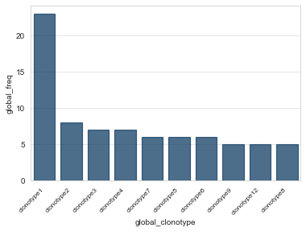

```python
clones.plot_top_clonotypes(count=10, metric="count", palette="ithaca", title=False,
                           x_text_angle=45, bar_outline=False, gridlines=True, alpha=0.7, label=True,
                           theme="pubr", bg_color="light")
```

### Frequency-Distribution

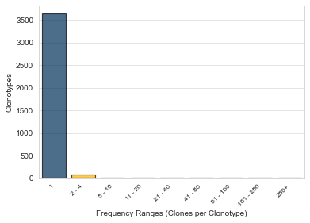

```python
clones.plot_clonotype_dist(palette="ithaca10", title=True, x_text_angle=45, bar_outline=True,
                    legend=True, gridlines=True, alpha=0.7, label=True, theme="pubr", bg_color="light")
```

Shown here, majority of our cells did not undergo immune activation in response to the APC-presented neoantigen [global_freq == 1 for the majority]

At this point, we have a handful of potential candidates if we choose a conservative cut-off:

Subset: global_freq > 1  
n_clonotypes=99  
n_cells=286

**Subsetting for global_freq > 1**:

```python
print(f'Number of barcode before subsetting: {len(clones)}')

# Subset on freq > 1.
clones_above_one = freq[freq['global_freq'] > 1]['global_clonotype'].values
clones_subset = clones[clones['global_clonotype'].isin(clones_above_one)]

# sanity_check = len(clones[clones['global_clonotype'].isin(clones_above_one)]) == sum(freq[freq['global_freq'] > 1]['global_freq'].values)
# print(sanity_check)

clones = clones_subset # Normalizing variables. Comment out and re-run everything after if you want to see whole dataset

# Subsetting with pandas methods converts to normal df. Converting back to Repseq here
clones = clp.Repseq(clones)

print(f'Number of barcodes after subsetting on clonally-expanded clonotypes: {len(clones)}')
```

[output not shown]

### VDJ-Frequency

Clonotypy provides easy functions to calculate frequency for V, D, J, and C genes (i.e *V,* D, ___J, etc.). `Repseq` objects can be easily converted to gene-count tables with the `to_GeneTable()` method. Another non-Repseq method, providing more flexible functionality is available as `analyze_genes()`.

```python
# Convert to GeneTable object
genes = clones.to_GeneTable()
genes.head(10)
```

|  | gene | count | vdj | chain | cell | isotype |
| --- | --- | --- | --- | --- | --- | --- |
| 1 | TRAV1-2 | 56 | v_gene | TRA | T-Cell (A/B) | n/a |
| 2 | TRBV7-6 | 34 | v_gene | TRB | T-Cell (A/B) | n/a |
| 3 | TRAV38-2/DV8 | 32 | v_gene | TRA | T-Cell (A/B) | n/a |
| 4 | TRBV20-1 | 27 | v_gene | TRB | T-Cell (A/B) | n/a |
| 5 | TRAV26-1 | 25 | v_gene | TRA | T-Cell (A/B) | n/a |
| 6 | TRAV21 | 22 | v_gene | TRA | T-Cell (A/B) | n/a |
| 7 | TRBV6-5 | 19 | v_gene | TRB | T-Cell (A/B) | n/a |
| 8 | TRBV4-3 | 19 | v_gene | TRB | T-Cell (A/B) | n/a |
| 9 | TRAV12-2 | 19 | v_gene | TRA | T-Cell (A/B) | n/a |
| 10 | TRBV12-4 | 17 | v_gene | TRB | T-Cell (A/B) | n/a |

```python
gene_descriptives = genes.describe_tcr()
gene_descriptives
```

|  | total_contig | perc.TRA | perc.TRB | top_v_gene | top_d_gene | top_j_gene | top_c_gene | top_TRAV | top_TRAD | top_TRAJ | top_TRAC | top_TRBV | top_TRBD | top_TRBJ | top_TRBC |
| --- | --- | --- | --- | --- | --- | --- | --- | --- | --- | --- | --- | --- | --- | --- | --- |
| 0 | 582 | 51.5 | 48.5 | TRAV1-2 | None | TRBJ2-1 | TRAC | TRAV1-2 | None | TRAJ33 | TRAC | TRBV7-6 | None | TRBJ2-1 | TRBC2 |

#### Plotting VDJ Frequency

Plot chain-specific VDJ segment (e.g., TRAV, TRBJ, IGKV etc.) counts for both TCR and Ig VDJ data.

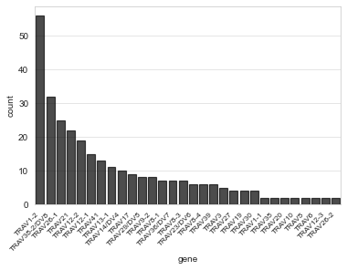

```python
clp.plot_vdj_by_segment(genes, segment='TRAV', palette="classic", bar_outline=True, x_text_angle=45,
                    gridlines=True, alpha=0.7, theme="pubr", label=True, bg_color="light")
```

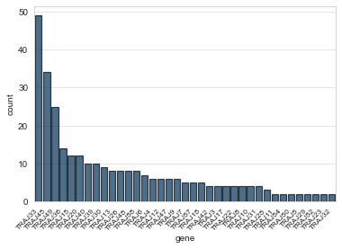

```python
clp.plot_vdj_by_segment(genes, segment='TRAJ', palette="ithaca", bar_outline=True, x_text_angle=45,
                    gridlines=True, alpha=0.7, theme="pubr", label=True, bg_color="light")
```

### VJ-Network

Calculate V-J pairing frequency in a network table. `Repseq` objects have the method `to_Network()`, but clonotypy also provides the underlying base function, `create_network()` to create the same data table.

```python
network = clp.create_network(clones, chain='TRA')
network
```

|  | from | to | value |
| --- | --- | --- | --- |
| 0 | TRAV1-2 | TRAJ33 | 47 |
| 1 | TRAV38-2/DV8 | TRAJ45 | 30 |
| 2 | TRAV26-1 | TRAJ49 | 23 |
| 3 | TRAV41 | TRAJ58 | 8 |
| 4 | TRAV36/DV7 | TRAJ15 | 7 |
| ... | ... | ... | ... |
| 68 | TRAV29/DV5 | TRAJ26 | 2 |
| 69 | TRAV29/DV5 | TRAJ29 | 2 |
| 70 | TRAV29/DV5 | TRAJ45 | 2 |
| 71 | TRAV29/DV5 | TRAJ48 | 2 |
| 72 | TRAV1-1 | TRAJ5 | 2 |

73 rows × 3 columns

#### Plotting V-J Networks

Clonotypy also provides functions for plotting three network graphs:

- `plot_network()` -- Directional Network Graphs
- `plot_chord()` -- Chord Diagrams
- `plot_sankey()` -- Sankey Diagrams

Network Graph

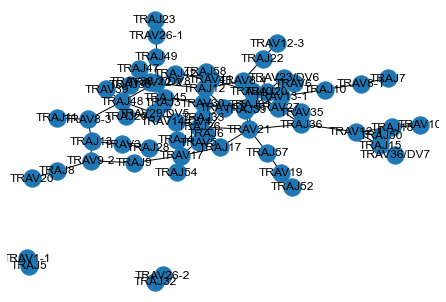

```python
clp.plot_network(network)
```

Sankey Diagram

```python
clp.plot_sankey(network, width=800, height=1000)
```

[interactive chart not shown]

### CDR3-Lengths

Investigate the frequency distribution of CDR3 chain lengths. `melt_cdr3()` will rapidly melt all CDR3 chains in your data down to a more simplistic structure for chain analysis. `plot_lengths_by_chains()` is one of the functions offered to visualize the CDR3 chain-length data.

```python
melted_chains = clp.melt_cdr3(clones)
melted_chains.head(10)
```

|  | global_clonotype | cell_type | productivity | chain | aa_seq | aa_length | nt_seq | nt_length |
| --- | --- | --- | --- | --- | --- | --- | --- | --- |
| 450 | clonotype1 | T-Cell | multi | TRA | CIVRGPRNTGNQFYF | 15.0 | TGCATCGTCAGAGGGCCACGGAACACCGGTAACCAGTTCTATTTT | 45.0 |
| 529 | clonotype1 | T-Cell | multi | TRA | CIVRGPRNTGNQFYF | 15.0 | TGCATCGTCAGAGGGCCACGGAACACCGGTAACCAGTTCTATTTT | 45.0 |
| 387 | clonotype1 | T-Cell | multi | TRA | CIVRGPRNTGNQFYF | 15.0 | TGCATCGTCAGAGGGCCACGGAACACCGGTAACCAGTTCTATTTT | 45.0 |
| 533 | clonotype1 | T-Cell | multi | TRA | CIVRGPRNTGNQFYF | 15.0 | TGCATCGTCAGAGGGCCACGGAACACCGGTAACCAGTTCTATTTT | 45.0 |
| 178 | clonotype1 | T-Cell | multi | TRB | CASSLEVGGGEETQYF | 16 | TGTGCCAGCAGCTTAGAAGTAGGGGGGGGTGAAGAGACCCAGTACTTC | 48 |
| 220 | clonotype1 | T-Cell | multi | TRB | CASSLEVGGGEETQYF | 16 | TGTGCCAGCAGCTTAGAAGTAGGGGGGGGTGAAGAGACCCAGTACTTC | 48 |
| 380 | clonotype1 | T-Cell | multi | TRA | CIVRGPRNTGNQFYF | 15.0 | TGCATCGTCAGAGGGCCACGGAACACCGGTAACCAGTTCTATTTT | 45.0 |
| 231 | clonotype1 | T-Cell | multi | TRB | CASSLEVGGGEETQYF | 16 | TGTGCCAGCAGCTTAGAAGTAGGGGGGGGTGAAGAGACCCAGTACTTC | 48 |
| 539 | clonotype1 | T-Cell | multi | TRA | CIVRGPRNTGNQFYF | 15.0 | TGCATCGTCAGAGGGCCACGGAACACCGGTAACCAGTTCTATTTT | 45.0 |
| 100 | clonotype1 | T-Cell | multi | TRB | CASSLEVGGGEETQYF | 16 | TGTGCCAGCAGCTTAGAAGTAGGGGGGGGTGAAGAGACCCAGTACTTC | 48 |

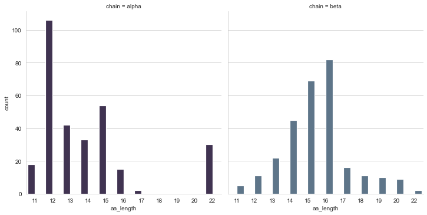

```python
clp.plot_lengths_by_chain(melted_chains, cell_type="T", plot_type="facet", cdr3="aa",
                          palette="bold", bar_outline=False, legend=True,
                          gridlines=True, alpha=0.7, label=True,
                          theme="pubr", bg_color="light", aspect=1)
```

### CDR3aa-Composition

Clonotypy has several functions related to the amino acid composition off CDR3 chains. These functions are primarily focused on calculating [position weight matrices (PWM)](https://www.ncbi.nlm.nih.gov/pmc/articles/PMC3820676/), but can also be represented as position frequency (PFM) or probability matrices (PPM) as well.

The position matrices can each be used to plot heatmaps or seqlogos for a given amino acid chain length to further characterize the chemical composition.

`Repseq` objects can be converted to position matrices via the `to_PositionMatrix()` method which has the flexibility to specify `matrix_type`(pfm, ppm, pwm), `cdr3_length`, `cdr3`(aa or nt, for amino acid or nucleotide), `chain`(receptor chain), `pseudocount`, and more.

```python
# Position Frequency Matrix
pfm = clones.to_PositionMatrix(matrix_type='pfm',
                               length=15,
                               cdr3='aa',
                               chain='TRA',
                               pseudocount=1,
                               col_prefix='p')
pfm
```

[output not shown]

```python
pfm.plot_matrix(palette='immunovue', annot=True, linecolor="#ffffff", linewidths=1)
```

[output not shown]

```python
pfm.plot_seqlogo(palette='immunovue', alpha=1)
```

[output not shown]

Easily convert between different position matrices:

```python
clp.composition.pfm_to_ppm(pd.DataFrame(pfm))
```

[output not shown]

## Beyond-Basics

Clonotypy is intended to help investigate **multiple** sequencing runs, or replicates. Therefore, it's primary functionality extends beyond the basic descriptive statistics provided in this tutorial.

The full functionality of this package is planned to be released Fall 2021. If you would like to contact the developer directly, please email mf@mattfemia.com